# Probability Sampling Results 2021

Alene Onion and Tony Olsen of USEPA (updated by Sabrina Xie)

Last compiled 31 January, 2022, 14:54:49

```r
options(knitr.duplicate.label = 'allow')
```

Historically, lakes were selected for NYS sampling based on their importance to recreation. We are shifting our focus to understand the health of NYS ponded waters for drinking water, recreation, and aquatic life designated uses. Therefore, we felt it was necessary to conduct an unbiased survey to best understand conditions across NYS ponded waters.

This analysis was conducted in collaboration with USEPA. Specifically, we collaborated with Tony Olsen and Michael Dumelle.

## Prepping data

Merging relevant raw data files and filtering

Please note that these were the criteria for selecting the original data frame: restricted to waterbodies in the NHD classified as LakePond which includes reservoirs, restricted to those above 6.5 acres, within the boundaries of NYS, we further excluded wetlands by examining satellite imagery and removing sites that are more than 50% covered by emergent macrophytes

```r
library(tidyverse)
library(huxtable)
library(ggplot2)
library(lubridate)

# retrieve raw data from database
setwd("~/OneDrive - New York State Office of Information Technology Services/Rscripts/Current")
source("new_database/Reading.LMAS.Data.R")
setwd("~/OneDrive - New York State Office of Information Technology Services/Rscripts/Probability.Sampling/")

rm(list=setdiff(ls(), c('newdata')))

lab<-newdata %>%
  filter(SAMPLE_DATE>'2020-01-01') %>%
  mutate(combined=paste(CHARACTERISTIC_NAME,
                        INFORMATION_TYPE,
                        RSLT_RESULT_SAMPLE_FRACTION,
                        sep = "_"))  %>%
  select(LAKE_HISTORY_ID,
         SAMPLE_DATE,
         combined,
         RSLT_RESULT_VALUE,
         RSLT_LABORATORY_QUALIFIER,
         RSLT_VALIDATOR_QUALIFIER,
         RSLT_PROFILE_DEPTH) %>%
  mutate(RSLT_RESULT_VALUE=ifelse(!is.na(RSLT_LABORATORY_QUALIFIER)&(RSLT_LABORATORY_QUALIFIER=="U"|RSLT_LABORATORY_QUALIFIER=="UE"),"0",RSLT_RESULT_VALUE),
         RSLT_RESULT_VALUE=as.numeric(RSLT_RESULT_VALUE)) %>%
  filter(!is.na(RSLT_RESULT_VALUE),
         is.na(RSLT_VALIDATOR_QUALIFIER)|(RSLT_VALIDATOR_QUALIFIER!="R"),
         combined %in% c('CHLOROPHYLL A_OW_TOTAL',
                         'PHOSPHORUS, TOTAL_OW_TOTAL',
                         "MICROCYSTIN_OW_NA",
                         "NITROGEN, NITRATE (AS N)_OW_TOTAL",
                         "NITROGEN, NITRATE-NITRITE_OW_TOTAL",
                         "NITROGEN, KJELDAHL, TOTAL_OW_TOTAL",
                         "NITROGEN, TOTAL_OW_TOTAL",
                         "DISSOLVED OXYGEN_DP_NA",
                         "TRUE COLOR_OW_TOTAL",
                         "PH_DP_NA",
                         "SPECIFIC CONDUCTANCE_DP_NA",
                         "TEMPERATURE_DP_NA",
                         "DEPTH, SECCHI DISK DEPTH_SD_NA",
                         "CALCIUM_OW_TOTAL",
                         "CHLORIDE_OW_TOTAL")) %>%
  select(LAKE_HISTORY_ID,SAMPLE_DATE,combined,RSLT_RESULT_VALUE,RSLT_PROFILE_DEPTH) %>%
  distinct(LAKE_HISTORY_ID,SAMPLE_DATE,combined,RSLT_PROFILE_DEPTH,.keep_all = TRUE) %>%
  rename(LAKE_ID=LAKE_HISTORY_ID,
         chemical_name=combined,
         result_value=RSLT_RESULT_VALUE,
         profile_depth=RSLT_PROFILE_DEPTH)

   # dissolved oxygen:
   # keep DO values between 0 and 2m depth
lab2 <- lab %>%
   mutate(keep=case_when(
     !(chemical_name=="DISSOLVED OXYGEN_DP_NA") ~ "no",
     chemical_name=="DISSOLVED OXYGEN_DP_NA" & profile_depth <= 2 ~ "yes",
     chemical_name=="DISSOLVED OXYGEN_DP_NA" & profile_depth > 2 ~ "no")) %>%
   filter(keep!="no") %>%
   select(-keep)

# mean DO for each lake each date
DO <- aggregate(lab2$result_value,list(lab2$LAKE_ID,lab2$SAMPLE_DATE),FUN=mean) %>%
  mutate(chemical_name="DISSOLVED OXYGEN_epi") %>%
  rename(LAKE_ID=Group.1,
         SAMPLE_DATE=Group.2,
         result_value=x)

#thermocline
thermocline<-lab %>%
  filter(chemical_name=='TEMPERATURE_DP_NA') %>%
  mutate(thermocline=NA)
LID<-thermocline$LAKE_ID[1]
date<-thermocline$SAMPLE_DATE[1]
depth<-thermocline$profile_depth[1]
temp<-thermocline$result_value[1]

for(i in seq(nrow(thermocline))){
  current<-thermocline[i,]
  if(current$LAKE_ID==LID&current$SAMPLE_DATE==date){
      depth=current$profile_depth
      if((temp-current$result_value)>1){
        thermocline$thermocline[i]<-current$profile_depth
      }
      temp=current$result_value
  }
  else{
    LID=current$LAKE_ID
    date=current$SAMPLE_DATE
    depth=current$profile_depth
    temp=current$result_value
  }
}

thermocline<-thermocline %>%  #pull the lowest value for all
  group_by(LAKE_ID,SAMPLE_DATE) %>%
  mutate(thermocline=min(thermocline, na.rm=T)) %>%
  ungroup() %>%
  mutate(thermocline=ifelse(thermocline==Inf,NA,thermocline)) %>%
  select(LAKE_ID,SAMPLE_DATE,thermocline,profile_depth) %>%
  filter(!is.na(thermocline)) %>%   #remove those without a thermocline
  distinct()

#epilimentic means for ph and spconductance
epi<-lab %>%
  inner_join(thermocline,by=c('LAKE_ID','SAMPLE_DATE','profile_depth')) %>%
  filter(chemical_name %in% c("PH_DP_NA","SPECIFIC CONDUCTANCE_DP_NA")) %>%
  mutate(result_value = ifelse(chemical_name=="PH_DP_NA",(10^result_value),result_value)) %>%
  distinct() %>%
  arrange(LAKE_ID,SAMPLE_DATE,chemical_name,profile_depth)

epi<-epi %>%
  filter(profile_depth<=thermocline) %>%
  distinct() %>%
  group_by(LAKE_ID,SAMPLE_DATE,chemical_name) %>%
  summarize(Mean=mean(result_value,na.rm=TRUE),
            n=n()) %>%
  filter(n>2) %>%
  select(LAKE_ID,SAMPLE_DATE,chemical_name,Mean)

epi<-epi %>%
  mutate(Mean=ifelse(chemical_name=="PH_DP_NA",log10(Mean),Mean)) %>%
  rename(result_value=Mean) %>%
  mutate(chemical_name=case_when(
    chemical_name=="PH_DP_NA"~"PH_epi",
    chemical_name=="SPECIFIC CONDUCTANCE_DP_NA"~"SPECIFIC CONDUCTANCE_epi"
  ))

# read in site data
sites<-read.csv("Probability_Based_Sites_2020_2021.csv")
sites<-sites %>%
  rename(siteID=SITE_ID,
         xcoord=LON_DD83,
         ycoord=LAT_DD83,
         Eval_Status=EvalStatus) %>%
  filter(Eval_Status!="") %>%    #removing sites that we haven't yet evaluated
  mutate(Eval_Status=trimws(Eval_Status))

# restrict to only the data in the probability study and spread the data
att<-merge(lab,epi,by=c("LAKE_ID","SAMPLE_DATE","chemical_name"),all=TRUE) %>%
  filter(chemical_name %in% c('CHLOROPHYLL A_OW_TOTAL',
                              'PHOSPHORUS, TOTAL_OW_TOTAL',
                              "MICROCYSTIN_OW_NA",
                              "NITROGEN, NITRATE-NITRITE_OW_TOTAL",
                              "NITROGEN, KJELDAHL, TOTAL_OW_TOTAL",
                              "NITROGEN, TOTAL_OW_TOTAL",
                              "NITROGEN, NITRATE (AS N)_OW_TOTAL",
                              "TRUE COLOR_OW_TOTAL",
                              "SPECIFIC CONDUCTANCE_epi",
                              "PH_epi",
                              "DISSOLVED OXYGEN_epi",
                              "DEPTH, SECCHI DISK DEPTH_SD_NA",
                              "CALCIUM_OW_TOTAL",
                              "CHLORIDE_OW_TOTAL")) %>%
  mutate(result_value=ifelse(is.na(result_value.x),result_value.y,result_value.x)) %>%
  select(-result_value.x,-result_value.y)
att<-merge(att,DO,by=c("LAKE_ID","SAMPLE_DATE","chemical_name"),all=TRUE)%>%
  filter(chemical_name %in% c('CHLOROPHYLL A_OW_TOTAL',
                              'PHOSPHORUS, TOTAL_OW_TOTAL',
                              "MICROCYSTIN_OW_NA",
                              "NITROGEN, NITRATE-NITRITE_OW_TOTAL",
                              "NITROGEN, KJELDAHL, TOTAL_OW_TOTAL",
                              "NITROGEN, TOTAL_OW_TOTAL",
                              "NITROGEN, NITRATE (AS N)_OW_TOTAL",
                              "TRUE COLOR_OW_TOTAL",
                              "SPECIFIC CONDUCTANCE_epi",
                              "PH_epi",
                              "DISSOLVED OXYGEN_epi",
                              "DEPTH, SECCHI DISK DEPTH_SD_NA",
                              "CALCIUM_OW_TOTAL",
                              "CHLORIDE_OW_TOTAL")) %>%
  mutate(result_value=ifelse(is.na(result_value.x),result_value.y,result_value.x)) %>%
  select(-result_value.x,-result_value.y)
```

```r
att<-merge(att,sites,by=c('LAKE_ID'),all.y = TRUE) %>% distinct()
att<-att %>% spread(chemical_name,result_value,fill = NA)

# selecting parameters and adding trophic status
att<-att %>%
  # remove fields in the sites table that aren't relevant
  select(-Accessible,-Comments,-Contact,-STATUS) %>%
  # create total nitrogen
  mutate(`NITROGEN, TOTAL`=case_when(
    !is.na(`NITROGEN, KJELDAHL, TOTAL_OW_TOTAL`) ~
      (`NITROGEN, NITRATE-NITRITE_OW_TOTAL`+`NITROGEN, KJELDAHL, TOTAL_OW_TOTAL`),
    is.na(`NITROGEN, KJELDAHL, TOTAL_OW_TOTAL`) ~ `NITROGEN, TOTAL_OW_TOTAL`)) %>%
  # DIN:TP
  mutate(DINTP=`NITROGEN, NITRATE (AS N)_OW_TOTAL`/`PHOSPHORUS, TOTAL_OW_TOTAL`) %>%
  # trophic status
  mutate(phos_trophic=case_when(
    `PHOSPHORUS, TOTAL_OW_TOTAL`<=0.01 ~ "oligotrophic",
    between(`PHOSPHORUS, TOTAL_OW_TOTAL`,0.01,0.02) ~ "mesotrophic",
    `PHOSPHORUS, TOTAL_OW_TOTAL`>=0.02 ~ "eutrophic")) %>%
  mutate(chla_trophic=case_when(
    `CHLOROPHYLL A_OW_TOTAL`<=2 ~ "oligotrophic",
    between(`CHLOROPHYLL A_OW_TOTAL`,2,8) ~ "mesotrophic",
    `CHLOROPHYLL A_OW_TOTAL`>=8 ~ "eutrophic")) %>%
  # EPA thresholds
  mutate(TP_threshold=case_when(
    `PHOSPHORUS, TOTAL_OW_TOTAL`<=0.016 ~ "Good",
    between(`PHOSPHORUS, TOTAL_OW_TOTAL`, 0.016, 0.0279) ~ "Fair",
    `PHOSPHORUS, TOTAL_OW_TOTAL`>=0.0279 ~ "Poor")) %>%
  mutate(TN_threshold=case_when(
    `NITROGEN, TOTAL`<=0.428 ~ "Good",
    between(`NITROGEN, TOTAL`, 0.428, 0.655) ~ "Fair",
    `NITROGEN, TOTAL`>=0.655 ~ "Poor")) %>%
  mutate(CHLA_threshold=case_when(
    `CHLOROPHYLL A_OW_TOTAL`<=4.52 ~ "Good",
    between(`CHLOROPHYLL A_OW_TOTAL`, 4.52, 8.43) ~ "Fair",
    `CHLOROPHYLL A_OW_TOTAL`>=8.43 ~ "Poor")) %>%
  # microcystin
  mutate(microcystin=case_when(
    is.na(`MICROCYSTIN_OW_NA`) ~"Non-detect",
    `MICROCYSTIN_OW_NA`<8 ~ "Microcystin Detected",
    `MICROCYSTIN_OW_NA`>=8 ~ "Most disturbed")) %>%
  # dissolved oxygen
  mutate(d.oxygen=case_when(
    `DISSOLVED OXYGEN_epi`<=3 ~ "Poor",
    between(`DISSOLVED OXYGEN_epi`, 3, 5) ~ "Fair",
    `DISSOLVED OXYGEN_epi`>=5 ~ "Good")) %>%
  #nutrient limitation
  mutate(N_LIMIT=case_when(
    `NITROGEN, TOTAL`/`PHOSPHORUS, TOTAL_OW_TOTAL`<=10 ~ "N-limiited",
    between(`NITROGEN, TOTAL`/`PHOSPHORUS, TOTAL_OW_TOTAL`, 10, 20) ~ "Co-limited",
    `NITROGEN, TOTAL`/`PHOSPHORUS, TOTAL_OW_TOTAL`>=20 ~ "P-limited")) %>%
  #ph
  mutate(ph_hypo=case_when(
    `PH_epi`<=6.5 ~ "Acidic",
    between(`PH_epi`, 6.5, 8.5) ~ "Circumneutral",
    `PH_epi`>=8.5 ~ "Alkaline")) %>%
  #secchi
  mutate(secchi=case_when(
    `DEPTH, SECCHI DISK DEPTH_SD_NA`<=2 ~ "eutrophic",
    between(`DEPTH, SECCHI DISK DEPTH_SD_NA`, 2, 5) ~ "mesotrophic",
    `DEPTH, SECCHI DISK DEPTH_SD_NA`>=5 ~ "oligotrophic")) %>%
  #zebra mussels
  mutate(zebra=case_when(
    CALCIUM_OW_TOTAL<=10 ~ "Not susceptible",
    between(CALCIUM_OW_TOTAL, 10, 20) ~ "May be susceptible",
    CALCIUM_OW_TOTAL>=20 ~ "Highly susceptible")) %>%
  #cslap
  mutate(conductance=case_when(
    `SPECIFIC CONDUCTANCE_epi`<=125 ~ "Softwater",
    between(`SPECIFIC CONDUCTANCE_epi`, 125, 250) ~ "Average",
    `SPECIFIC CONDUCTANCE_epi`>=250 ~ "Hardwater")) %>%
  mutate(color=case_when(
    `TRUE COLOR_OW_TOTAL`<=10 ~ "Uncolored",
    between(`TRUE COLOR_OW_TOTAL`, 10, 30) ~ "Weakly colored",
    `TRUE COLOR_OW_TOTAL`>=30 ~ "Colored")) %>%
  mutate(ph=case_when(
    `PH_epi`<=6.5 ~ "Acidic",
    between(`PH_epi`, 6.5, 7.5) ~ "Circumneutral",
    between(`PH_epi`, 7.5, 8.5) ~ "Slightly alkaline",
    `PH_epi`>=8.5 ~ "Highly alkaline")) %>%
  #leech
  mutate(leech=case_when(
    `PHOSPHORUS, TOTAL_OW_TOTAL`<=0.030 & `TRUE COLOR_OW_TOTAL`<=20 ~ "Blue",
    `PHOSPHORUS, TOTAL_OW_TOTAL`>0.030 & `TRUE COLOR_OW_TOTAL`<=20 ~ "Green",
    `PHOSPHORUS, TOTAL_OW_TOTAL`<=0.030 & `TRUE COLOR_OW_TOTAL`>20 ~ "Brown",
    `PHOSPHORUS, TOTAL_OW_TOTAL`>0.030 & `TRUE COLOR_OW_TOTAL`>20 ~ "Murky"
  )) %>%
  #chloride
  mutate(chloride=case_when(
    `CHLORIDE_OW_TOTAL` <= 25 ~ "Low",
    between(`CHLORIDE_OW_TOTAL`,25,100) ~ "Medium",
    `CHLORIDE_OW_TOTAL` >= 100 ~ "High",
    Eval_Status=="Target_Sampled" & is.na(`CHLORIDE_OW_TOTAL`) ~ "Low"))

# Create a Target/NonTarget status variable
att<-att %>%
  mutate(statusTNT="Target",
         statusTNT=ifelse(Eval_Status=="NonTarget","NonTarget",statusTNT))

# get duplicates (multiple samples of same lake)
n_occur <- data.frame(table(att$FID))
dupes <- att[att$FID %in% n_occur$Var1[n_occur$Freq > 1],]

# keep most recent august sample
m_att <- att %>%
  mutate(keep=case_when(
    FID %in% dupes$FID & month(SAMPLE_DATE) != 9 & !is.na(`CHLOROPHYLL A_OW_TOTAL`) ~ "yes",
    !(FID %in% dupes$FID) ~ "yes")) %>%
  arrange(FID,desc(SAMPLE_DATE)) %>%
  filter(keep=="yes")

m_occur <- data.frame(table(m_att$FID))
m_att <- m_att[!duplicated(m_att$FID),]

att <- m_att %>%
  distinct()

# Calculate the adjusted weights
# The numerator is the original frame size value
# the denominator is the actual number of samples evaluated in each category

#number of lakes in each probability category
cats <- data.frame(
  PROB_CAT=unique(att$PROB_CAT),
  n=as.double(1,2,3,4,5))

for(i in 1:5){
  b <- cats[i,1]
  a <- att %>%
    filter(PROB_CAT==b)
  cats[i,2] <- nrow(a)
}

# add adjusted weight variable
att<-att %>%
  mutate(WgtAdj=case_when(
         PROB_CAT=="(1,4]"~(1828/29),
         PROB_CAT=="(4,10]"~(2490/15),
         PROB_CAT=="(10,20]"~(1003/18),
         PROB_CAT=="(20,50]"~(616/20),
         PROB_CAT==">50"~(500/33)))

# should add up to 6437
print(sum(att$WgtAdj))
```

[1] 6437

## Analysis

The start of the NYSAnalysis code from Tony Olsen

The results are weighted based on the distribution of the five size classes in the original data frame divided by the distribution in the samples evaluated. The purpose of this step is to account for oversampling in certain size classes.

PLEASE NOTE: the samples evaluated included the lakes that were actually sampled as well as the lakes which could not be sampled due to wetland status or access issues. After adjusting the weights, they should add up to the original frame size of 6437.

Non-target samples are those determined to be wetlands using GIS analysis. Target samples include lakes actually sampled as well as lakes we intended to sample but couldn’t for access or wetland status reasons. The following code uses the sample population of target/non-target samples (NResp) to project how many of the total 6437 lakes in our data frame would have been target/non-target (Estimate.U) as well as the 95% confidence interval (LCB95Pct.U and UCB95Pct.U).

```r
framesize_LC <- c("New York State"=116)

# Estimate TNT extent
library(spsurvey)
TNTextent <- cat_analysis(
  dframe=att,
  vars=c("statusTNT"),
  subpops = ,
  siteID = "siteID",
  weight = "WgtAdj",
  xcoord = "xcoord",
  ycoord = "ycoord")
table <- TNTextent %>% select(Category,nResp,Estimate.U,LCB95Pct.U,UCB95Pct.U)
hux <- as_hux(table)
number_format(hux) <- 2
theme_plain(hux)
```

| Category | nResp | Estimate.U | LCB95.00Pct.U | UCB95.00Pct.U |
| --- | --- | --- | --- | --- |
| NonTarget | 18.00 | 1294.60 | 762.70 | 1826.50 |
| Target | 97.00 | 5142.40 | 4285.96 | 5998.83 |
| Total | 115.00 | 6437.00 | 5580.25 | 7293.75 |

This code uses the same logic to estimate the ratios in the target population that were actually sampled versus inaccessible or wetland status.

```r
# Estimate Target extent reasons
target.att <- att[att$statusTNT=="Target",]
TargetExtent <- cat_analysis(
  dframe=target.att,
  vars=c("Eval_Status"),
  subpops = ,
  siteID = "siteID",
  weight = "WgtAdj",
  xcoord = "xcoord",
  ycoord = "ycoord")
table <- TargetExtent %>% select(Category,nResp,Estimate.U,LCB95Pct.U,UCB95Pct.U)
hux <- as_hux(table)
number_format(hux) <- 2
theme_plain(hux)
```

| Category | nResp | Estimate.U | LCB95.00Pct.U | UCB95.00Pct.U |
| --- | --- | --- | --- | --- |
| Target_NoOwnerAccess | 31.00 | 2106.63 | 1478.55 | 2734.70 |
| Target_PhysicalAccess | 5.00 | 458.60 | 73.77 | 843.42 |
| Target_Sampled | 61.00 | 2577.17 | 1919.72 | 3234.62 |
| Total | 97.00 | 5142.40 | 4351.28 | 5933.51 |

## Comparison to NYS thresholds

PLEAE NOTE: this presumes that the lakes we didn’t sample were random. A reasonable assumption but it’s obviously preferable to sample all the lakes in the list to avoid this uncertainty.

```r
##### Trophic classes #####
# Estimate assessment result
CatExtent2 <- cat_analysis(
  dframe=att,
  vars=c("chla_trophic","phos_trophic","secchi"),
  subpops = ,
  siteID = "siteID",
  weight = "WgtAdj",
  xcoord = "xcoord",
  ycoord = "ycoord")

#quickly calculate the percentages
totals<-CatExtent2 %>%
  select(Indicator,Category,Estimate.U) %>%
  rename(total=Estimate.U)
totals[totals$Indicator=="chla_trophic",3] <- CatExtent2$Estimate.U[4]
totals[totals$Indicator=="phos_trophic",3] <- CatExtent2$Estimate.U[8]
totals[totals$Indicator=="secchi",3] <- CatExtent2$Estimate.U[12]
CatExtent2<-merge(CatExtent2,totals,by=c('Indicator','Category'),all.x = TRUE)

forplot2<-CatExtent2 %>%
  mutate(pct=(Estimate.U/total)*100,
         pct_lcb=(LCB95Pct.U/total)*100,
         pct_ucb=(UCB95Pct.U/total)*100) %>%
  select(Indicator,Category,pct,pct_lcb,pct_ucb) %>%
  distinct() %>%
  filter(Category!="Total") %>%
  gather(percent,results,-Indicator,-Category) %>%
  mutate(Indicator=ifelse(Indicator=="chla_trophic","Trophic Status from ChlA",Indicator),
         Indicator=ifelse(Indicator=="phos_trophic","Trophic Status from Phosphorus",Indicator),
         Indicator=ifelse(Indicator=="secchi","Trophic Status from Secchi",Indicator))

table <- forplot2 %>%
  spread(percent,results)  %>%
  rename(Percentage=pct,Lower95Confidence=pct_lcb,Upper95Confidence=pct_ucb)

hux <- as_hux(table)
number_format(hux) <- 2
theme_plain(hux)
```

| Indicator | Category | Percentage | Lower95.00Confidence | Upper95.00Confidence |
| --- | --- | --- | --- | --- |
| Trophic Status from ChlA | eutrophic | 9.18 | 2.88 | 15.48 |
| Trophic Status from ChlA | mesotrophic | 70.32 | 45.82 | 94.82 |
| Trophic Status from ChlA | oligotrophic | 20.50 | 5.86 | 35.13 |
| Trophic Status from Phosphorus | eutrophic | 22.48 | 9.56 | 35.40 |
| Trophic Status from Phosphorus | mesotrophic | 32.08 | 12.77 | 51.38 |
| Trophic Status from Phosphorus | oligotrophic | 45.44 | 27.37 | 63.52 |
| Trophic Status from Secchi | eutrophic | 47.69 | 28.59 | 66.80 |
| Trophic Status from Secchi | mesotrophic | 47.49 | 28.62 | 66.36 |
| Trophic Status from Secchi | oligotrophic | 4.82 | 1.03 | 8.61 |

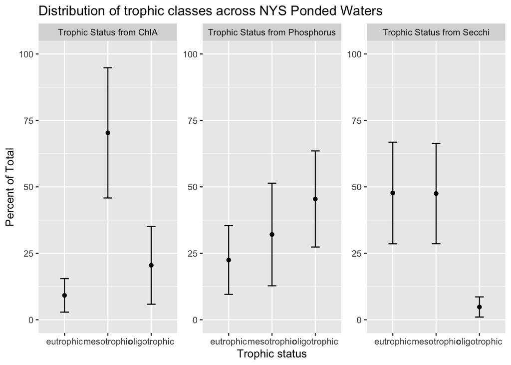

```r
forplot2$Category <- factor(forplot2$Category, levels=c("oligotrophic", "mesotrophic", "eutrophic"))

ggplot(table,aes(x=Category,y=Percentage)) +
  geom_point()+
  geom_errorbar(aes(ymin=Lower95Confidence,ymax=Upper95Confidence),width=0.2)+
  theme(legend.position = "none")+
  facet_wrap(~Indicator,scales = "free_y")+
  ylim(0,100)+
  labs(title="Distribution of trophic classes across NYS Ponded Waters",y="Percent of Total",x="Trophic status")
```

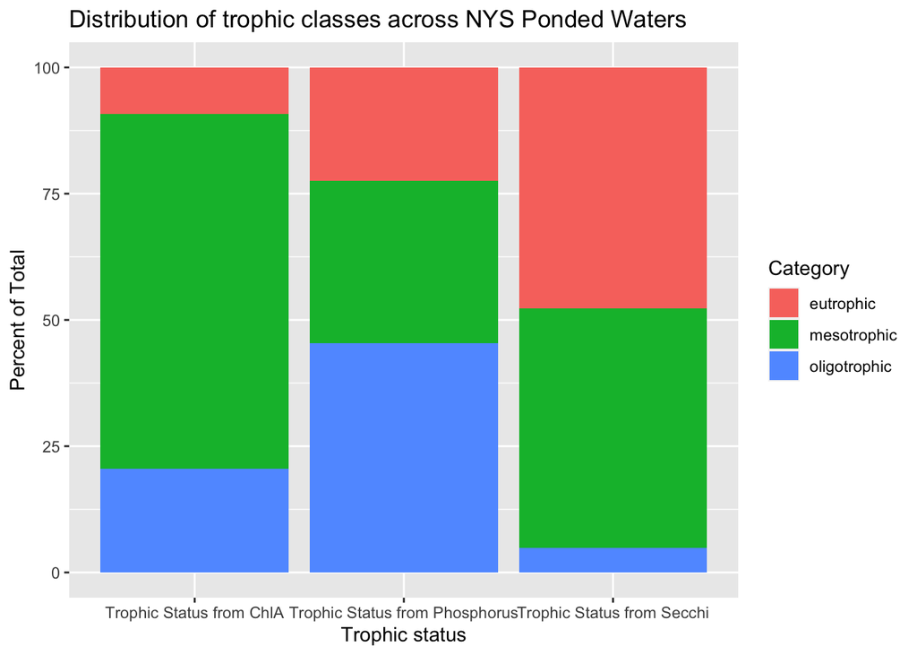

```r
ggplot(table,aes(x=Indicator,y=Percentage,fill=Category)) +
  geom_bar(stat = "identity",position="stack")+
  labs(title="Distribution of trophic classes across NYS Ponded Waters",y="Percent of Total",x="Trophic status")
```

```r
##### N limitation #####
#  Estimate assessment result
nlimit <- cat_analysis(
  dframe=att,
  vars=c("N_LIMIT"),
  subpops = ,
  siteID = "siteID",
  weight = "WgtAdj",
  xcoord = "xcoord",
  ycoord = "ycoord")

#quickly calculate the percentages
totals<-nlimit %>%
  select(Indicator,Category,Estimate.U) %>%
  rename(total=Estimate.U)
totals$total <- nlimit$Estimate.U[4]
nlimit<-merge(nlimit,totals,by=c('Indicator','Category'),all.x = TRUE)

forplot<-nlimit %>%
  mutate(pct=(Estimate.U/total)*100,
         pct_lcb=(LCB95Pct.U/total)*100,
         pct_ucb=(UCB95Pct.U/total)*100) %>%
  select(Indicator,Category,pct,pct_lcb,pct_ucb) %>%
  distinct() %>%
  filter(Category!="Total") %>%
  gather(percent,results,-Indicator,-Category) %>%
  mutate(Indicator=ifelse(Indicator=="N_LIMIT","Nutrient limitation category",Indicator))

table <- forplot %>%
  spread(percent,results)  %>%
  rename(Percentage=pct,Lower95Confidence=pct_lcb,Upper95Confidence=pct_ucb)

hux <- as_hux(table)
number_format(hux) <- 2
theme_plain(hux)
```

| Indicator | Category | Percentage | Lower95.00Confidence | Upper95.00Confidence |
| --- | --- | --- | --- | --- |
| Nutrient limitation category | Co-limited | 15.53 | 0.00 | 32.32 |
| Nutrient limitation category | N-limiited | 0.97 | 0.00 | 2.65 |
| Nutrient limitation category | P-limited | 83.50 | 59.03 | 107.97 |

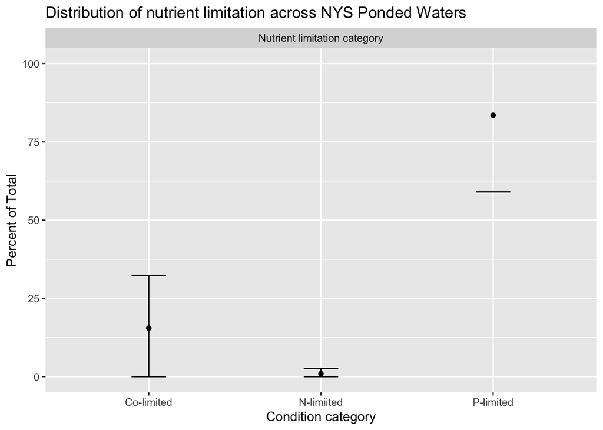

```r
ggplot(table,aes(x=Category,y=Percentage)) +
  geom_point()+
  geom_errorbar(aes(ymin=Lower95Confidence,ymax=Upper95Confidence),width=0.2)+
  theme(legend.position = "none")+
  facet_wrap(~Indicator,scales = "free_y")+
  ylim(0,100)+
  labs(title="Distribution of nutrient limitation across NYS Ponded Waters",y="Percent of Total",x="Condition category")
```

```r
##### Chloride #####
#  Estimate assessment result
chloride <- cat_analysis(
  dframe=att,
  vars=c("chloride"),
  subpops = ,
  siteID = "siteID",
  weight = "WgtAdj",
  xcoord = "xcoord",
  ycoord = "ycoord")

#quickly calculate the percentages
totals<-chloride %>%
  select(Indicator,Category,Estimate.U) %>%
  rename(total=Estimate.U)
totals$total <- chloride$Estimate.U[4]
chloride<-merge(chloride,totals,by=c('Indicator','Category'),all.x = TRUE)

forplot<-chloride %>%
  mutate(pct=(Estimate.U/total)*100,
         pct_lcb=(LCB95Pct.U/total)*100,
         pct_ucb=(UCB95Pct.U/total)*100) %>%
  select(Indicator,Category,pct,pct_lcb,pct_ucb) %>%
  distinct() %>%
  filter(Category!="Total") %>%
  gather(percent,results,-Indicator,-Category) %>%
  mutate(Indicator=ifelse(Indicator=="chloride","Chloride",Indicator))

table <- forplot %>%
  spread(percent,results)  %>%
  rename(Percentage=pct,Lower95Confidence=pct_lcb,Upper95Confidence=pct_ucb)

hux <- as_hux(table)
number_format(hux) <- 2
theme_plain(hux)
```

| Indicator | Category | Percentage | Lower95.00Confidence | Upper95.00Confidence |
| --- | --- | --- | --- | --- |
| Chloride | High | 1.20 | 0.00 | 3.20 |
| Chloride | Low | 82.94 | 60.41 | 105.47 |
| Chloride | Medium | 15.87 | 4.73 | 27.00 |

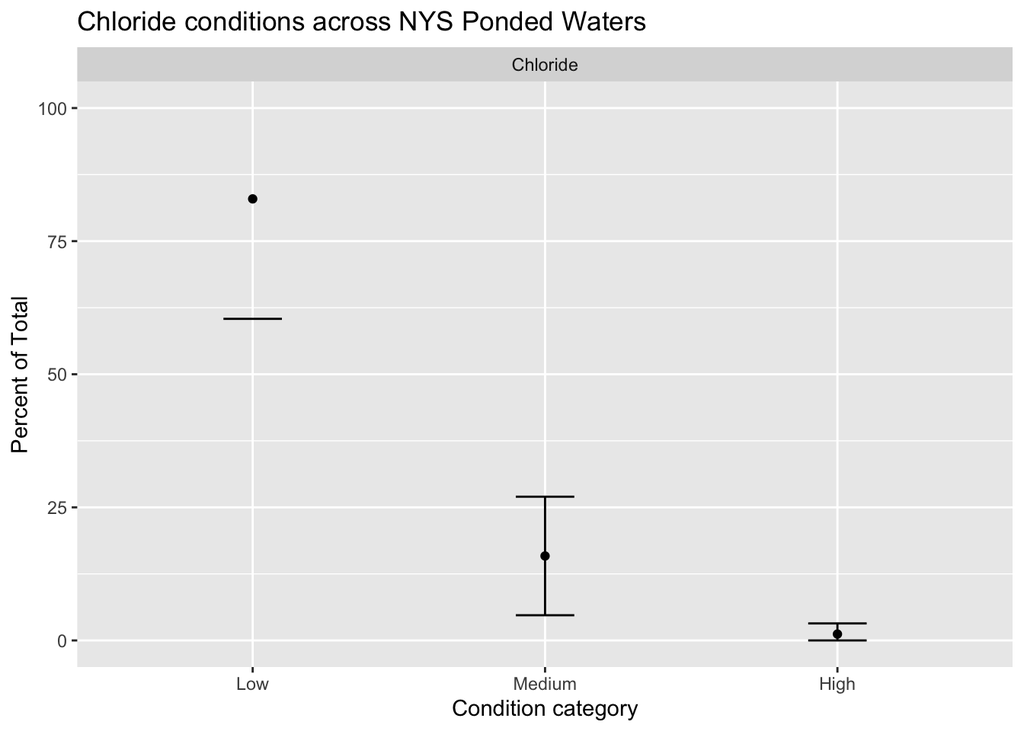

```r
table$Category <- factor(table$Category, levels=c("Low", "Medium", "High"))

ggplot(table,aes(x=Category,y=Percentage)) +
  geom_point()+
  geom_errorbar(aes(ymin=Lower95Confidence,ymax=Upper95Confidence),width=0.2)+
  theme(legend.position = "none")+
  facet_wrap(~Indicator,scales = "free_y")+
  ylim(0,100)+
  labs(title="Chloride conditions across NYS Ponded Waters",y="Percent of Total",x="Condition category")
```

```r
##### Trophic classes #####
# Estimate assessment result
CatExtent2 <- cat_analysis(
  dframe=att,
  vars=c("chla_trophic","phos_trophic","secchi"),
  subpops = ,
  siteID = "siteID",
  weight = "WgtAdj",
  xcoord = "xcoord",
  ycoord = "ycoord")

#quickly calculate the percentages
totals<-CatExtent2 %>%
  select(Indicator,Category,Estimate.U) %>%
  rename(total=Estimate.U)
totals[totals$Indicator=="chla_trophic",3] <- CatExtent2$Estimate.U[4]
totals[totals$Indicator=="phos_trophic",3] <- CatExtent2$Estimate.U[8]
CatExtent2<-merge(CatExtent2,totals,by=c('Indicator','Category'),all.x = TRUE)

forplot2<-CatExtent2 %>%
  mutate(pct=(Estimate.U/total)*100,
         pct_lcb=(LCB95Pct.U/total)*100,
         pct_ucb=(UCB95Pct.U/total)*100) %>%
  select(Indicator,Category,pct,pct_lcb,pct_ucb) %>%
  distinct() %>%
  filter(Category!="Total") %>%
  gather(percent,results,-Indicator,-Category) %>%
  mutate(Indicator=ifelse(Indicator=="chla_trophic","Trophic Status from ChlA",Indicator),
         Indicator=ifelse(Indicator=="phos_trophic","Trophic Status from Phosphorus",Indicator))

table <- forplot2 %>%
  spread(percent,results)  %>%
  rename(Percentage=pct,Lower95Confidence=pct_lcb,Upper95Confidence=pct_ucb)

hux <- as_hux(table)
number_format(hux) <- 2
theme_plain(hux)
```

| Indicator | Category | Percentage | Lower95.00Confidence | Upper95.00Confidence |
| --- | --- | --- | --- | --- |
| secchi | eutrophic | 100.00 | 59.95 | 140.05 |
| secchi | mesotrophic | 100.00 | 60.27 | 139.73 |
| secchi | oligotrophic | 100.00 | 21.37 | 178.63 |
| Trophic Status from ChlA | eutrophic | 9.18 | 2.88 | 15.48 |
| Trophic Status from ChlA | mesotrophic | 70.32 | 45.82 | 94.82 |
| Trophic Status from ChlA | oligotrophic | 20.50 | 5.86 | 35.13 |
| Trophic Status from Phosphorus | eutrophic | 22.48 | 9.56 | 35.40 |
| Trophic Status from Phosphorus | mesotrophic | 32.08 | 12.77 | 51.38 |
| Trophic Status from Phosphorus | oligotrophic | 45.44 | 27.37 | 63.52 |

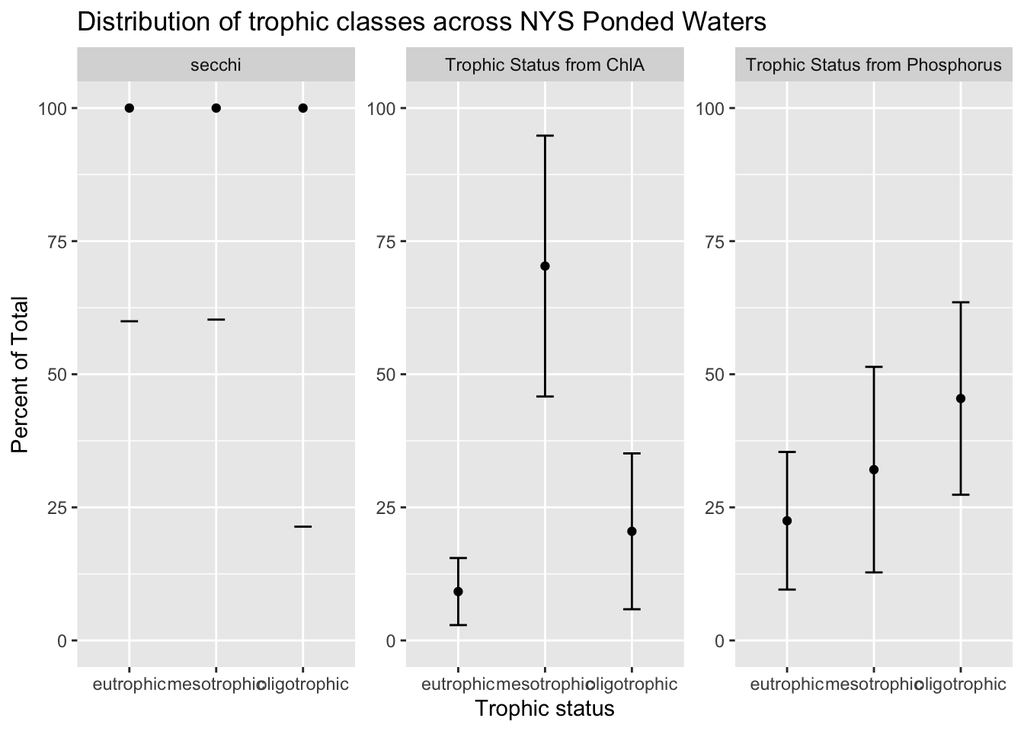

```r
forplot2$Category <- factor(forplot2$Category, levels=c("oligotrophic", "mesotrophic", "eutrophic"))

ggplot(table,aes(x=Category,y=Percentage)) +
  geom_point()+
  geom_errorbar(aes(ymin=Lower95Confidence,ymax=Upper95Confidence),width=0.2)+
  theme(legend.position = "none")+
  facet_wrap(~Indicator,scales = "free_y")+
  ylim(0,100)+
  labs(title="Distribution of trophic classes across NYS Ponded Waters",y="Percent of Total",x="Trophic status")
```

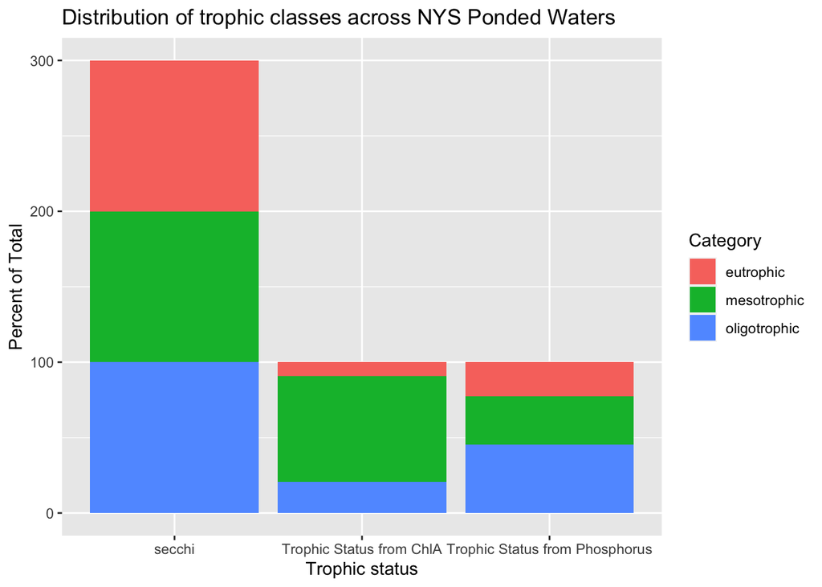

```r
ggplot(table,aes(x=Indicator,y=Percentage,fill=Category)) +
  geom_bar(stat = "identity",position="stack")+
  labs(title="Distribution of trophic classes across NYS Ponded Waters",y="Percent of Total",x="Trophic status")
```

```r
##### Zebra mussels #####
#  Estimate assessment result
zebra <- cat_analysis(
  dframe=att,
  vars=c("zebra"),
  subpops = ,
  siteID = "siteID",
  weight = "WgtAdj",
  xcoord = "xcoord",
  ycoord = "ycoord")

#quickly calculate the percentages
totals<-zebra %>%
  select(Indicator,Category,Estimate.U) %>%
  rename(total=Estimate.U)
totals$total <- zebra$Estimate.U[4]
zebra<-merge(zebra,totals,by=c('Indicator','Category'),all.x = TRUE)

forplt10<-zebra %>%
  mutate(pct=(Estimate.U/total)*100,
         pct_lcb=(LCB95Pct.U/total)*100,
         pct_ucb=(UCB95Pct.U/total)*100) %>%
  select(Indicator,Category,pct,pct_lcb,pct_ucb) %>%
  distinct() %>%
  filter(Category!="Total") %>%
  gather(percent,results,-Indicator,-Category) %>%
  mutate(Indicator=ifelse(Indicator=="zebra","Susceptibility",Indicator))

table <- forplt10 %>%
  spread(percent,results)  %>%
  rename(Percentage=pct,Lower95Confidence=pct_lcb,Upper95Confidence=pct_ucb)

table$Category <- factor(table$Category, levels=c("Not susceptible", "May be susceptible", "Highly susceptible"))

hux <- as_hux(table)
number_format(hux) <- 2
theme_plain(hux)
```

| Indicator | Category | Percentage | Lower95.00Confidence | Upper95.00Confidence |
| --- | --- | --- | --- | --- |
| Susceptibility | Highly susceptible | 28.46 | 10.38 | 46.54 |
| Susceptibility | May be susceptible | 14.24 | 0.00 | 31.95 |
| Susceptibility | Not susceptible | 57.31 | 30.59 | 84.02 |

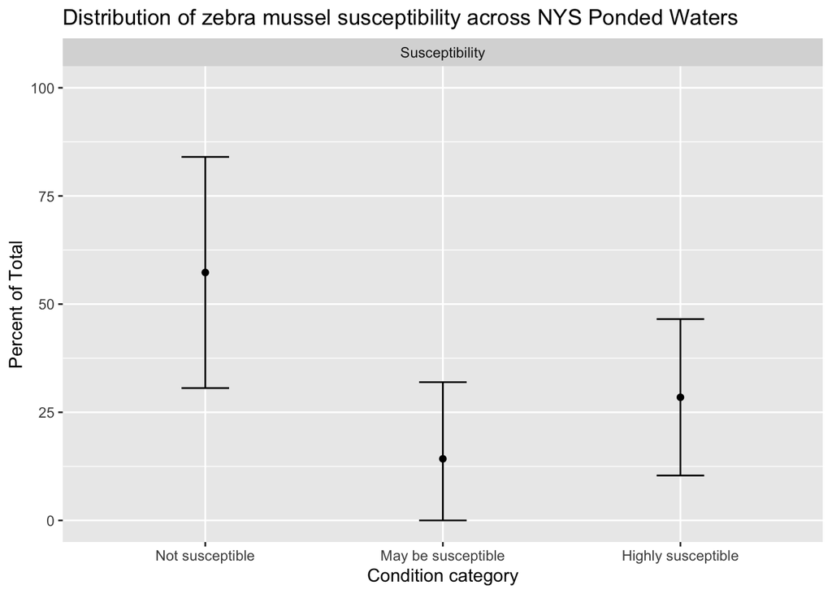

```r
ggplot(table,aes(x=Category,y=Percentage)) +
  geom_point()+
  geom_errorbar(aes(ymin=Lower95Confidence,ymax=Upper95Confidence),width=0.2)+
  theme(legend.position = "none")+
  facet_wrap(~Indicator,scales = "free_y")+
  ylim(0,100)+
  labs(title="Distribution of zebra mussel susceptibility across NYS Ponded Waters",y="Percent of Total",x="Condition category")
```

## Comparison to NLA thresholds

```r
##### EPA nutrient threshold #####
#  Estimate assessment result
CatExtent <- cat_analysis(
  dframe=att,
  vars=c("TP_threshold","CHLA_threshold","TN_threshold"),
  subpops = ,
  siteID = "siteID",
  weight = "WgtAdj",
  xcoord = "xcoord",
  ycoord = "ycoord")

#quickly calculate the percentages
totals<-CatExtent %>%
  select(Indicator,Category,Estimate.U) %>%
  rename(total=Estimate.U)
totals[totals$Indicator=="CHLA_threshold",3] <- CatExtent$Estimate.U[8]
totals[totals$Indicator=="TN_threshold",3] <- CatExtent$Estimate.U[12]
totals[totals$Indicator=="TP_threshold",3] <- CatExtent$Estimate.U[4]
CatExtent<-merge(CatExtent,totals,by=c('Indicator','Category'),all.x = TRUE)

forplot<-CatExtent %>%
  mutate(pct=(Estimate.U/total)*100,
         pct_lcb=(LCB95Pct.U/total)*100,
         pct_ucb=(UCB95Pct.U/total)*100) %>%
  select(Indicator,Category,pct,pct_lcb,pct_ucb) %>%
  distinct() %>%
  filter(Category!="Total") %>%
  gather(percent,results,-Indicator,-Category) %>%
  mutate(Indicator=ifelse(Indicator=="CHLA_threshold","ChlA",Indicator),
         Indicator=ifelse(Indicator=="TP_threshold","Phosphorus",Indicator),
         Indicator=ifelse(Indicator=="TN_threshold","Total Nitrogen",Indicator))

table <- forplot %>%
  spread(percent,results)  %>%
  rename(Percentage=pct,Lower95Confidence=pct_lcb,Upper95Confidence=pct_ucb)

hux <- as_hux(table)
number_format(hux) <- 2
theme_plain(hux)
```

| Indicator | Category | Percentage | Lower95.00Confidence | Upper95.00Confidence |
| --- | --- | --- | --- | --- |
| ChlA | Fair | 40.81 | 16.57 | 65.05 |
| ChlA | Good | 50.01 | 33.05 | 66.97 |
| ChlA | Poor | 9.18 | 2.88 | 15.48 |
| Phosphorus | Fair | 15.44 | 5.85 | 25.04 |
| Phosphorus | Good | 65.59 | 42.85 | 88.33 |
| Phosphorus | Poor | 18.97 | 6.22 | 31.72 |
| Total Nitrogen | Fair | 14.95 | 4.34 | 25.56 |
| Total Nitrogen | Good | 61.49 | 37.27 | 85.71 |
| Total Nitrogen | Poor | 23.57 | 6.99 | 40.14 |

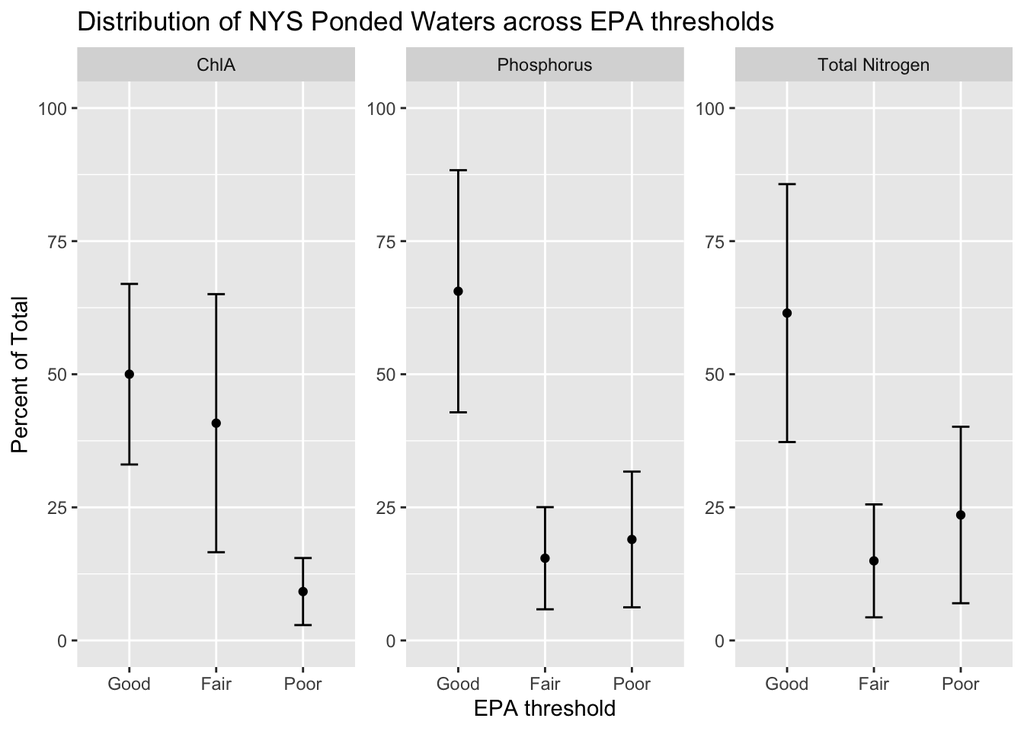

```r
table$Category <- factor(table$Category, levels=c("Good", "Fair", "Poor"))

ggplot(table,aes(x=Category,y=Percentage)) +
  geom_point()+
  geom_errorbar(aes(ymin=Lower95Confidence,ymax=Upper95Confidence),width=0.2)+
  theme(legend.position = "none")+
  facet_wrap(~Indicator,scales = "free_y")+
  ylim(0,100)+
  labs(title="Distribution of NYS Ponded Waters across EPA thresholds",y="Percent of Total",x="EPA threshold")
```

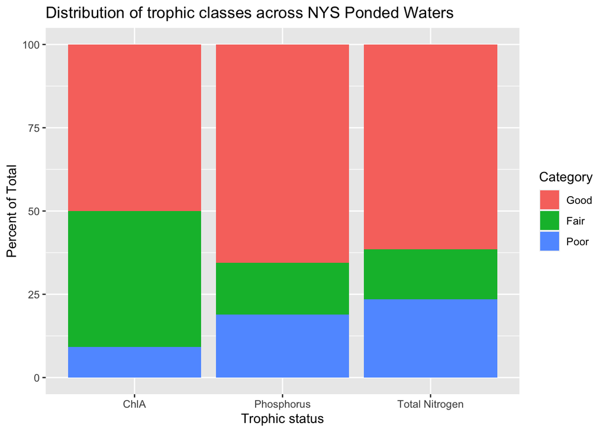

```r
ggplot(table,aes(x=Indicator,y=Percentage,fill=Category)) +
  geom_bar(stat = "identity",position="stack")+
  labs(title="Distribution of trophic classes across NYS Ponded Waters",y="Percent of Total",x="Trophic status")
```

```r
##### Microcystin #####
#  Estimate assessment result
MicExtent <- cat_analysis(
  dframe=att,
  vars=c("microcystin"),
  subpops = ,
  siteID = "siteID",
  weight = "WgtAdj",
  xcoord = "xcoord",
  ycoord = "ycoord")

#quickly calculate the percentages
totals<-MicExtent %>%
  select(Indicator,Category,Estimate.U) %>%
  rename(total=Estimate.U)
MicExtent<-merge(MicExtent,totals,by=c('Indicator','Category'),all.x = TRUE)

forplot3<-MicExtent %>%
  mutate(pct=(Estimate.U/total)*100,
         pct_lcb=(LCB95Pct.U/total)*100,
         pct_ucb=(UCB95Pct.U/total)*100) %>%
  select(Indicator,Category,pct,pct_lcb,pct_ucb) %>%
  distinct() %>%
  filter(Category!="Total") %>%
  gather(percent,results,-Indicator,-Category) %>%
  mutate(Indicator=ifelse(Indicator=="microcystin","Microsystin condition category",Indicator))

table <- forplot3 %>%
  spread(percent,results)  %>%
  rename(Percentage=pct,Lower95Confidence=pct_lcb,Upper95Confidence=pct_ucb)

hux <- as_hux(table)
number_format(hux) <- 2
theme_plain(hux)
```

| Indicator | Category | Percentage | Lower95.00Confidence | Upper95.00Confidence |
| --- | --- | --- | --- | --- |
| Microsystin condition category | Non-detect | 100.00 | 86.69 | 113.31 |

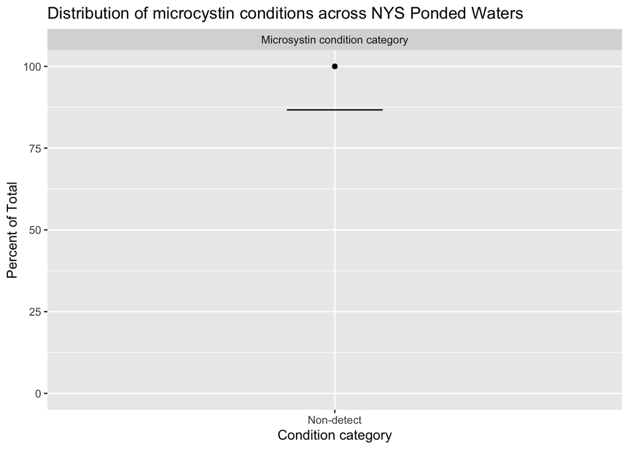

```r
table$Category <- factor(table$Category, levels=c("Non-detect","Microcystin disturbed"))

ggplot(table,aes(x=Category,y=Percentage)) +
  geom_point()+
  geom_errorbar(aes(ymin=Lower95Confidence,ymax=Upper95Confidence),width=0.2)+
  theme(legend.position = "none")+
  facet_wrap(~Indicator,scales = "free_y")+
  ylim(0,100)+
  labs(title="Distribution of microcystin conditions across NYS Ponded Waters",y="Percent of Total",x="Condition category")
```

Below, the analysis is done for each dissolved oxygen condition category.

```r
###### Dissolved oxygen #####
# Estimate assessment result
DOextent <- cat_analysis(
  dframe=att,
  vars=c("d.oxygen"),
  subpops = ,
  siteID = "siteID",
  weight = "WgtAdj",
  xcoord = "xcoord",
  ycoord = "ycoord")

#quickly calculate the percentages
totals<-DOextent %>%
  select(Indicator,Category,Estimate.U) %>%
  rename(total=Estimate.U)
totals$total <- DOextent$Estimate.U[4]
DOextent<-merge(DOextent,totals,by=c('Indicator','Category'),all.x = TRUE)

forplot4<-DOextent %>%
  mutate(pct=(Estimate.U/total)*100,
         pct_lcb=(LCB95Pct.U/total)*100,
         pct_ucb=(UCB95Pct.U/total)*100) %>%
  select(Indicator,Category,pct,pct_lcb,pct_ucb) %>%
  distinct() %>%
  filter(Category!="Total") %>%
  gather(percent,results,-Indicator,-Category) %>%
  mutate(Indicator=ifelse(Indicator=="d.oxygen","Dissolved Oxygen",Indicator))

table <- forplot4 %>%
  spread(percent,results)  %>%
  rename(Percentage=pct,Lower95Confidence=pct_lcb,Upper95Confidence=pct_ucb)

hux <- as_hux(table)
number_format(hux) <- 2
theme_plain(hux)
```

| Indicator | Category | Percentage | Lower95.00Confidence | Upper95.00Confidence |
| --- | --- | --- | --- | --- |
| Dissolved Oxygen | Fair | 1.25 | 0.00 | 3.36 |
| Dissolved Oxygen | Good | 91.39 | 69.86 | 112.92 |
| Dissolved Oxygen | Poor | 7.36 | 0.00 | 18.59 |

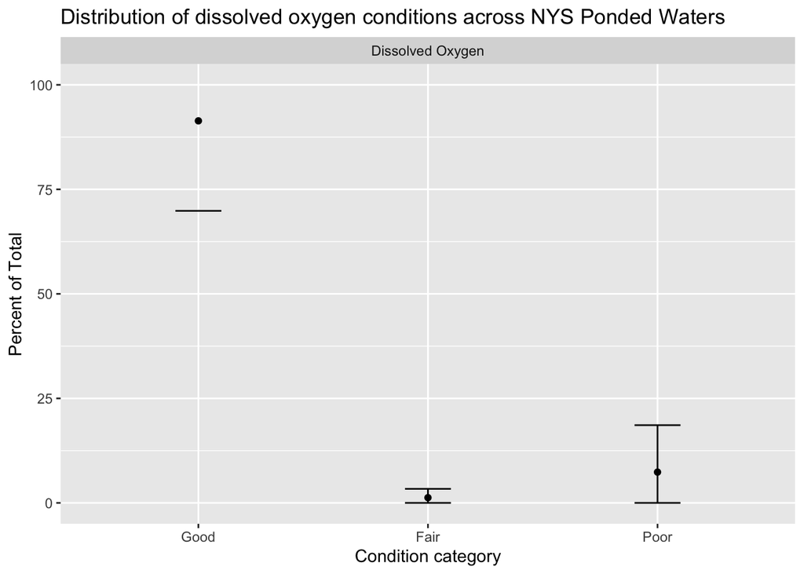

```r
table$Category <- factor(table$Category, levels=c("Good","Fair","Poor"))

ggplot(table,aes(x=Category,y=Percentage)) +
  geom_point()+
  geom_errorbar(aes(ymin=Lower95Confidence,ymax=Upper95Confidence),width=0.2)+
  theme(legend.position = "none")+
  facet_wrap(~Indicator,scales = "free_y")+
  ylim(0,100)+
  labs(title="Distribution of dissolved oxygen conditions across NYS Ponded Waters",y="Percent of Total",x="Condition category")
```

## Comparison to LMAS Samples

A plot below shows the distribution of the size classes included in the data frame. For comparison, I’ve plotted the proportion of NYS lakes sampled in each size class since 2010.

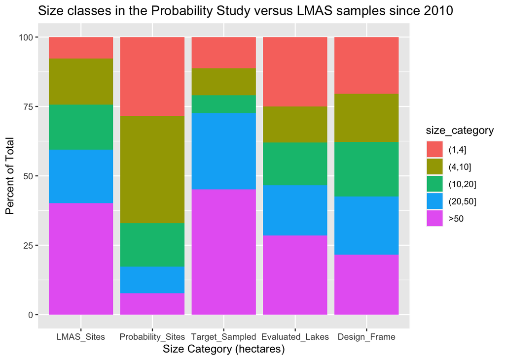

And the following plot shows the comparison of trophic distributions among LMAS most recent august samples since 2010 compared to the probability drawn samples. NOTE: used ecoregion analysis to generate the LMAS numbers. These are the most recent August sample collected from each lake sampled since 2010 (a total of 473 unique lakes were sampled since 2010).

[figure not shown]

$y [1] “Percent of Total”

$x [1] “Trophic Classes”

$title [1] “Trophic Classes in the Probability Study versus LMAS samples since 2010”

attr(,“class”) [1] “labels”

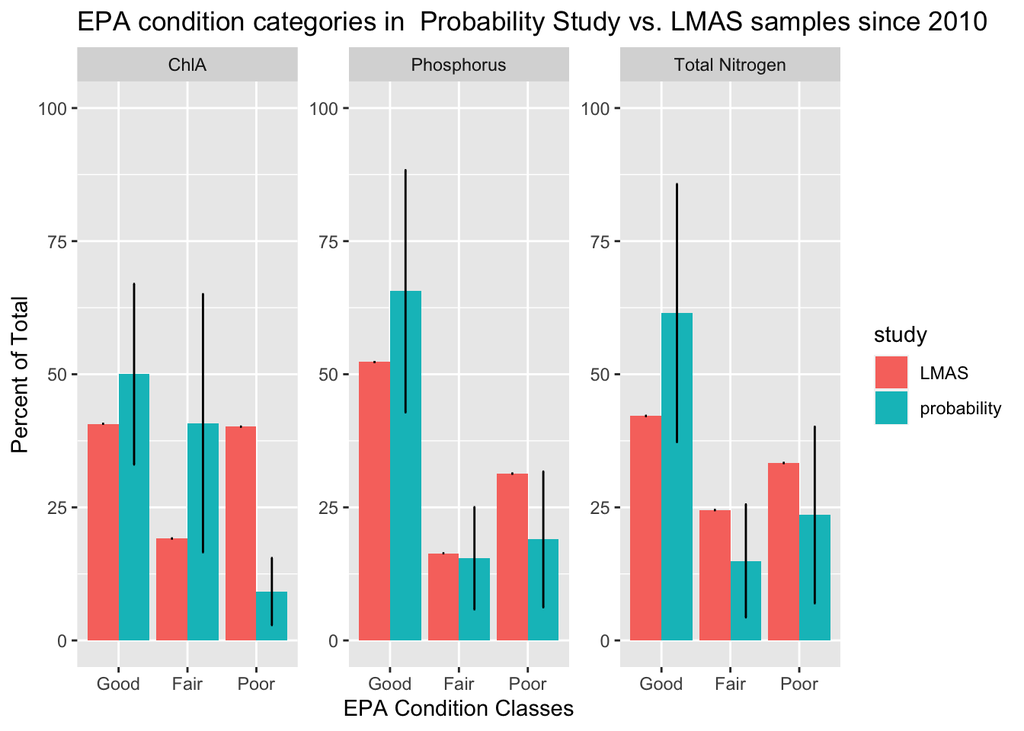

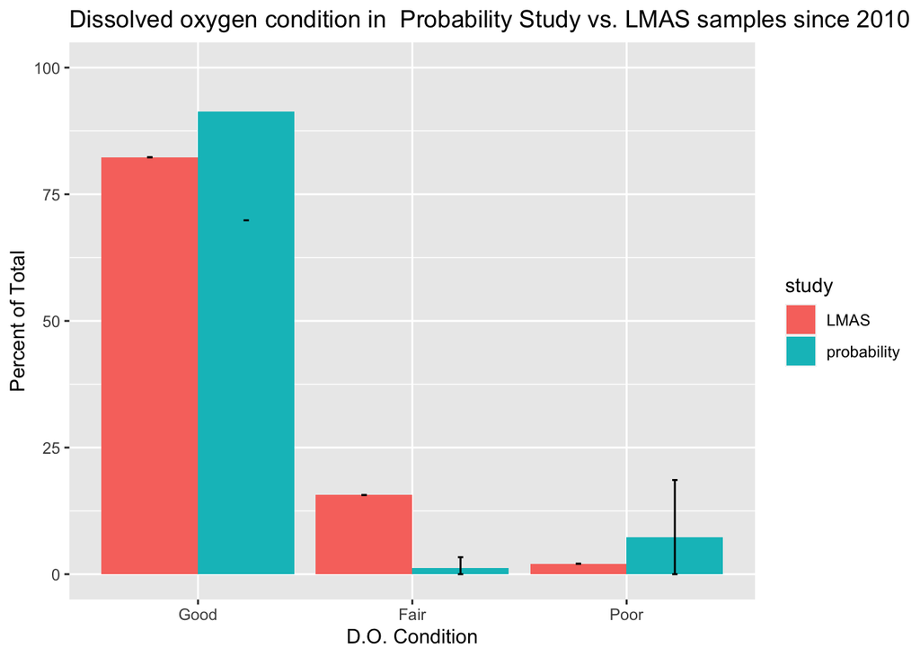

## CSLAP

| Indicator | Category | Percentage | Lower95.00Confidence | Upper95.00Confidence |
| --- | --- | --- | --- | --- |
| Water hardness | Average | 18.42 | 0.00 | 37.05 |
| Water hardness | Hardwater | 13.80 | 5.88 | 21.71 |
| Water hardness | Softwater | 67.78 | 45.30 | 90.27 |

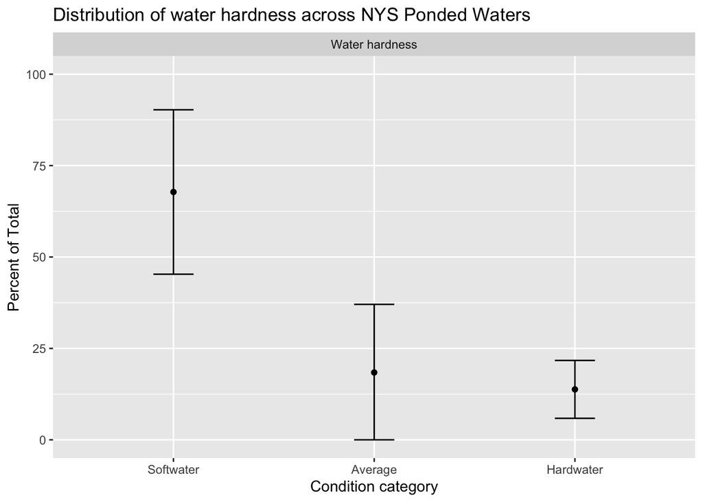

| Indicator | Category | Percentage | Lower95.00Confidence | Upper95.00Confidence |
| --- | --- | --- | --- | --- |
| Color condition category | Colored | 70.69 | 33.18 | 108.21 |
| Color condition category | Uncolored | 9.36 | 1.15 | 17.58 |
| Color condition category | Weakly colored | 19.94 | 8.07 | 31.82 |

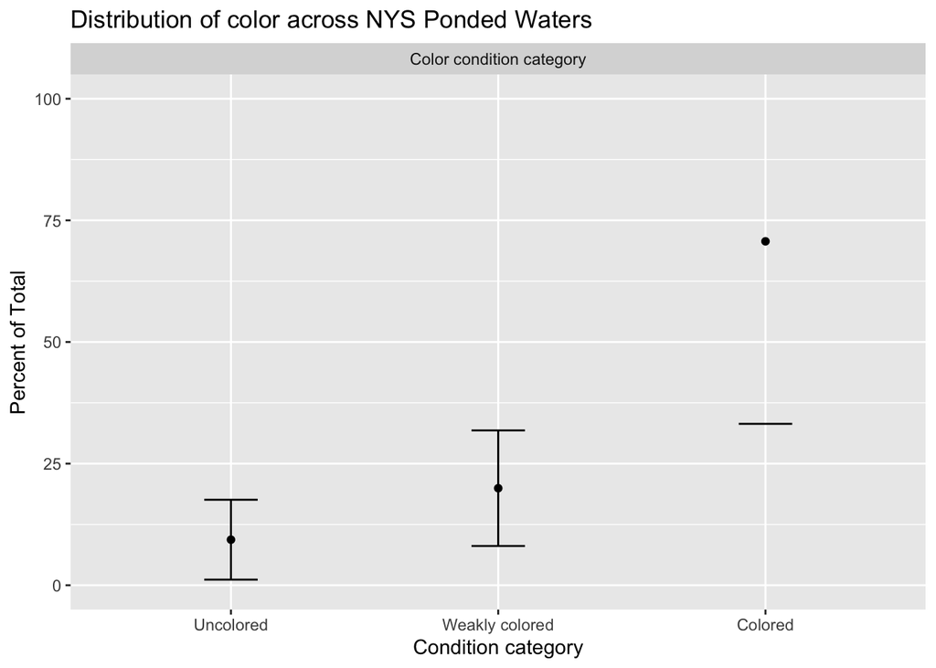

| Indicator | Category | Percentage | Lower95.00Confidence | Upper95.00Confidence |
| --- | --- | --- | --- | --- |
| pH condition category | Acidic | 7.49 | 0.34 | 14.65 |
| pH condition category | Circumneutral | 45.42 | 20.09 | 70.75 |
| pH condition category | Highly alkaline | 15.92 | 0.00 | 34.18 |
| pH condition category | Slightly alkaline | 31.16 | 19.20 | 43.13 |

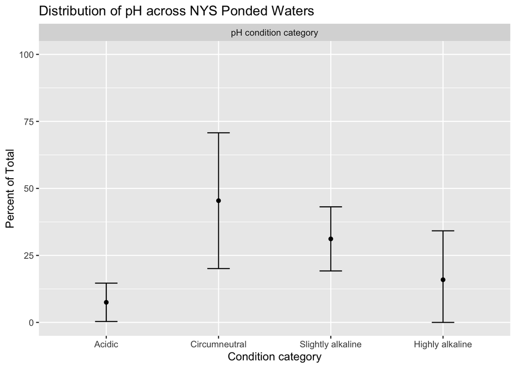

## Leech

Leech, D. M., Pollard, A. I., Labou, S. G., & Hampton, S. E. (2018). Fewer blue lakes and more murky lakes across the continental U.S.: Implications for planktonic food webs. Limnology and Oceanography, 63(6), 2661–2680. https://doi.org/10.1002/lno.10967

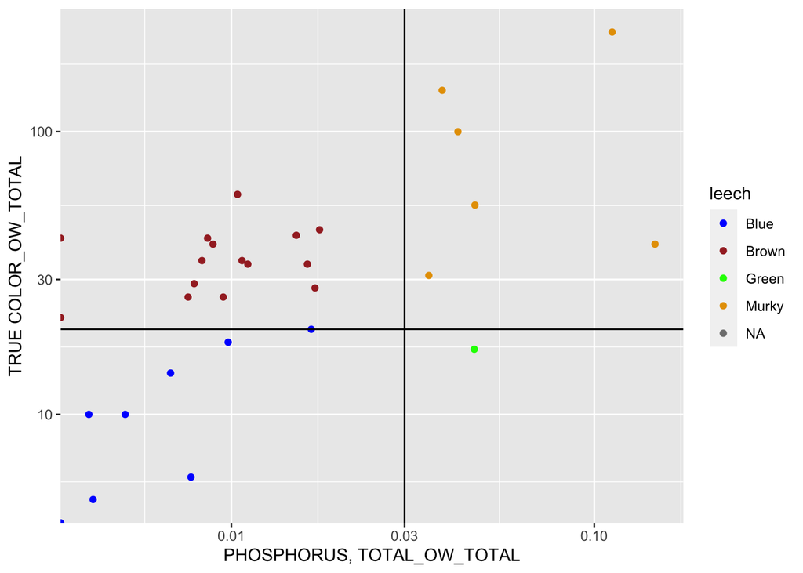

```r
print(
  ggplot(att,aes(x=`PHOSPHORUS, TOTAL_OW_TOTAL`,y=`TRUE COLOR_OW_TOTAL`,color=leech))+
    geom_point()+
    geom_vline(xintercept=0.030)+
    geom_hline(yintercept=20)+
    scale_y_continuous(trans='log10')+
    scale_x_continuous(trans='log10')+
    scale_color_manual(values=c("blue", "brown", "green","#E69F00")))
```

```r
##### Leech color #####
# Estimate assessment result
CatExtent2 <- cat_analysis(
  dframe=att,
  vars=c("leech"),
  subpops = ,
  siteID = "siteID",
  weight = "WgtAdj",
  xcoord = "xcoord",
  ycoord = "ycoord")

#quickly calculate the percentages
totals<-CatExtent2 %>%
  select(Indicator,Category,Estimate.U) %>%
  rename(total=Estimate.U)
totals$total <- CatExtent2$Estimate.U[5]
CatExtent2<-merge(CatExtent2,totals,by=c('Indicator','Category'),all.x = TRUE)

forplot2<-CatExtent2 %>%
  mutate(pct=(Estimate.U/total)*100,
         pct_lcb=(LCB95Pct.U/total)*100,
         pct_ucb=(UCB95Pct.U/total)*100) %>%
  select(Indicator,Category,pct,pct_lcb,pct_ucb) %>%
  distinct() %>%
  filter(Category!="Total") %>%
  gather(percent,results,-Indicator,-Category) %>%
  mutate(Indicator=ifelse(Indicator=="leech","Lake nutrient-color status",Indicator))

table <- forplot2 %>%
  spread(percent,results)  %>%
  rename(Percentage=pct,Lower95Confidence=pct_lcb,Upper95Confidence=pct_ucb)

hux <- as_hux(table)
number_format(hux) <- 2
theme_plain(hux)
```

| Indicator | Category | Percentage | Lower95.00Confidence | Upper95.00Confidence |
| --- | --- | --- | --- | --- |
| Lake nutrient-color status | Blue | 20.73 | 6.73 | 34.74 |
| Lake nutrient-color status | Brown | 52.22 | 20.26 | 84.18 |
| Lake nutrient-color status | Green | 1.22 | 0.00 | 3.35 |
| Lake nutrient-color status | Murky | 25.83 | 5.51 | 46.16 |

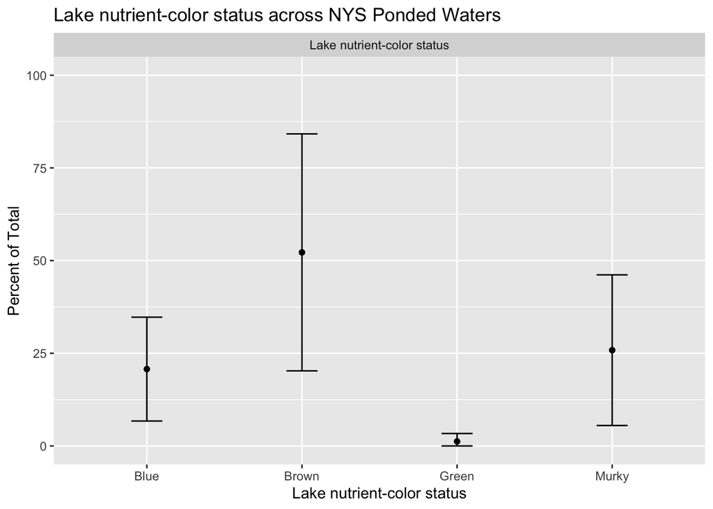

```r
ggplot(table,aes(x=Category,y=Percentage)) +
  geom_point()+
  geom_errorbar(aes(ymin=Lower95Confidence,ymax=Upper95Confidence),width=0.2)+
  theme(legend.position = "none")+
  facet_wrap(~Indicator,scales = "free_y")+
  ylim(0,100)+
  labs(title="Lake nutrient-color status across NYS Ponded Waters",y="Percent of Total",x="Lake nutrient-color status")
```

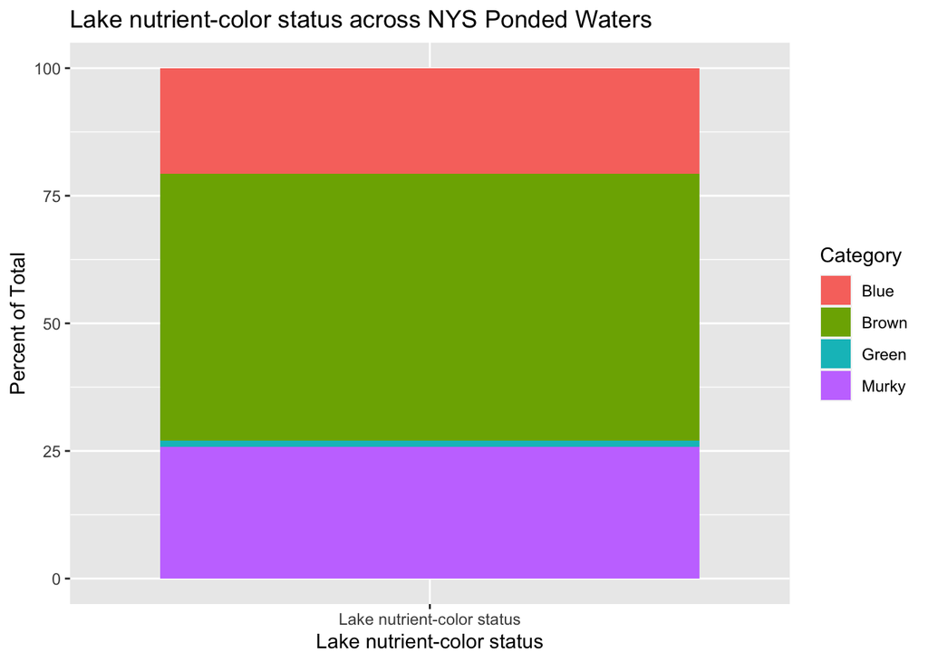

```r
ggplot(table,aes(x=Indicator,y=Percentage,fill=Category)) +
  geom_bar(stat = "identity",position="stack")+
  labs(title="Lake nutrient-color status across NYS Ponded Waters",y="Percent of Total",x="Lake nutrient-color status")
```

## Map

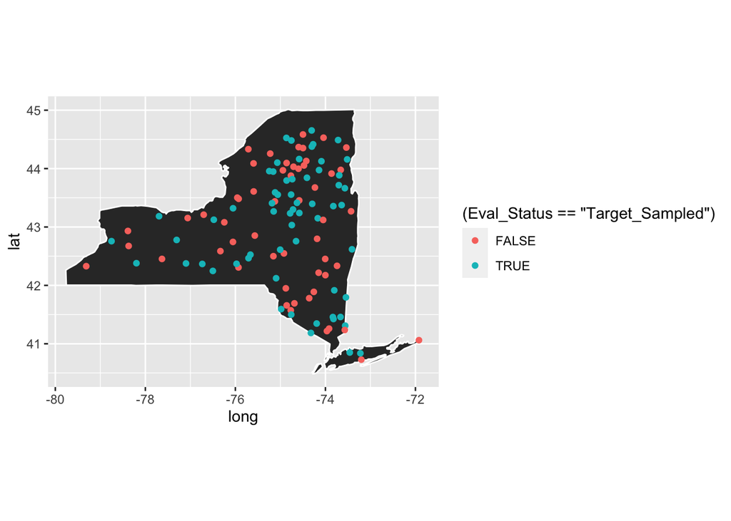

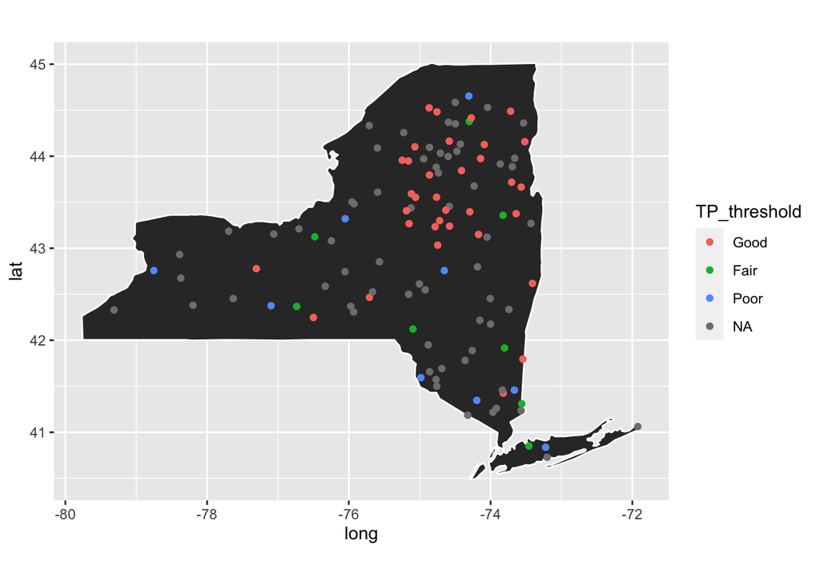

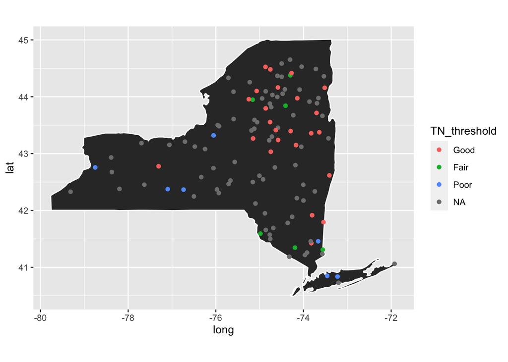

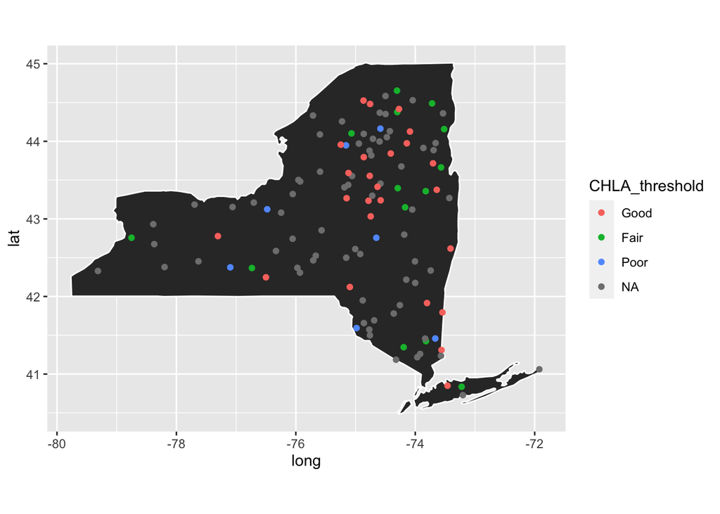

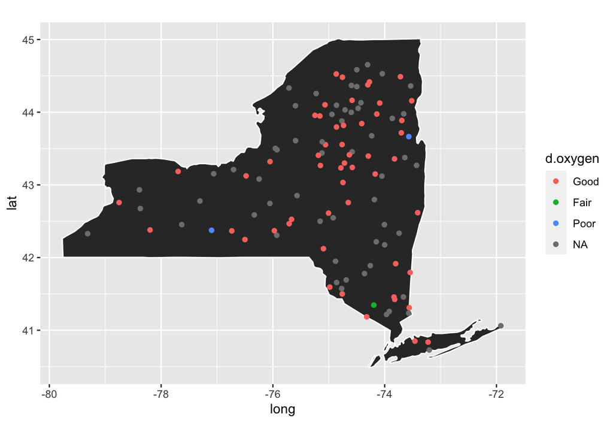